# menu_report

# Data

Below is a plain view of the raw data in menu.csv:

```
## # A tibble: 260 x 24
##    categ~1 item  servi~2 calor~3 calor~4 total~5 total~6 satur~7 satur~8 trans~9
##    <chr>   <chr> <chr>     <dbl>   <dbl>   <dbl>   <dbl>   <dbl>   <dbl>   <dbl>
##  1 Breakf~ Egg ~ 4.8 oz~     300     120      13      20       5      25       0
##  2 Breakf~ Egg ~ 4.8 oz~     250      70       8      12       3      15       0
##  3 Breakf~ Saus~ 3.9 oz~     370     200      23      35       8      42       0
##  4 Breakf~ Saus~ 5.7 oz~     450     250      28      43      10      52       0
##  5 Breakf~ Saus~ 5.7 oz~     400     210      23      35       8      42       0
##  6 Breakf~ Stea~ 6.5 oz~     430     210      23      36       9      46       1
##  7 Breakf~ Baco~ 5.3 oz~     460     230      26      40      13      65       0
##  8 Breakf~ Baco~ 5.8 oz~     520     270      30      47      14      68       0
##  9 Breakf~ Baco~ 5.4 oz~     410     180      20      32      11      56       0
## 10 Breakf~ Baco~ 5.9 oz~     470     220      25      38      12      59       0
## # ... with 250 more rows, 14 more variables: cholesterol <dbl>,
## #   cholesterol_percent_daily_value <dbl>, sodium <dbl>,
## #   sodium_percent_daily_value <dbl>, carbohydrates <dbl>,
## #   carbohydrates_percent_daily_value <dbl>, dietary_fiber <dbl>,
## #   dietary_fiber_percent_daily_value <dbl>, sugars <dbl>, protein <dbl>,
## #   vitamin_a_percent_daily_value <dbl>, vitamin_c_percent_daily_value <dbl>,
## #   calcium_percent_daily_value <dbl>, iron_percent_daily_value <dbl>, and ...
```

Another view of the raw data using an intractable table:

|  | category | item | serving_size | calories | calories_from_fat | total_fat | total_fat_percent_daily_value | saturated_fat | saturated_fat_percent_daily_value | trans_fat | cholesterol | cholesterol_percent_daily_value | sodium | sodium_percent_daily_value | carbohydrates | carbohydrates_percent_daily_value | dietary_fiber | dietary_fiber_percent_daily_value | sugars | protein | vitamin_a_percent_daily_value | vitamin_c_percent_daily_value | calcium_percent_daily_value | iron_percent_daily_value |
| --- | --- | --- | --- | --- | --- | --- | --- | --- | --- | --- | --- | --- | --- | --- | --- | --- | --- | --- | --- | --- | --- | --- | --- | --- |
| 1 | Breakfast | Egg McMuffin | 4.8 oz (136 g) | 300 | 120 | 13 | 20 | 5 | 25 | 0 | 260 | 87 | 750 | 31 | 31 | 10 | 4 | 17 | 3 | 17 | 10 | 0 | 25 | 15 |
| 2 | Breakfast | Egg White Delight | 4.8 oz (135 g) | 250 | 70 | 8 | 12 | 3 | 15 | 0 | 25 | 8 | 770 | 32 | 30 | 10 | 4 | 17 | 3 | 18 | 6 | 0 | 25 | 8 |
| 3 | Breakfast | Sausage McMuffin | 3.9 oz (111 g) | 370 | 200 | 23 | 35 | 8 | 42 | 0 | 45 | 15 | 780 | 33 | 29 | 10 | 4 | 17 | 2 | 14 | 8 | 0 | 25 | 10 |
| 4 | Breakfast | Sausage McMuffin with Egg | 5.7 oz (161 g) | 450 | 250 | 28 | 43 | 10 | 52 | 0 | 285 | 95 | 860 | 36 | 30 | 10 | 4 | 17 | 2 | 21 | 15 | 0 | 30 | 15 |
| 5 | Breakfast | Sausage McMuffin with Egg Whites | 5.7 oz (161 g) | 400 | 210 | 23 | 35 | 8 | 42 | 0 | 50 | 16 | 880 | 37 | 30 | 10 | 4 | 17 | 2 | 21 | 6 | 0 | 25 | 10 |
| 6 | Breakfast | Steak &amp; Egg McMuffin | 6.5 oz (185 g) | 430 | 210 | 23 | 36 | 9 | 46 | 1 | 300 | 100 | 960 | 40 | 31 | 10 | 4 | 18 | 3 | 26 | 15 | 2 | 30 | 20 |
| 7 | Breakfast | Bacon, Egg &amp; Cheese Biscuit (Regular Biscuit) | 5.3 oz (150 g) | 460 | 230 | 26 | 40 | 13 | 65 | 0 | 250 | 83 | 1300 | 54 | 38 | 13 | 2 | 7 | 3 | 19 | 10 | 8 | 15 | 15 |
| 8 | Breakfast | Bacon, Egg &amp; Cheese Biscuit (Large Biscuit) | 5.8 oz (164 g) | 520 | 270 | 30 | 47 | 14 | 68 | 0 | 250 | 83 | 1410 | 59 | 43 | 14 | 3 | 12 | 4 | 19 | 15 | 8 | 20 | 20 |
| 9 | Breakfast | Bacon, Egg &amp; Cheese Biscuit with Egg Whites (Regular Biscuit) | 5.4 oz (153 g) | 410 | 180 | 20 | 32 | 11 | 56 | 0 | 35 | 11 | 1300 | 54 | 36 | 12 | 2 | 7 | 3 | 20 | 2 | 8 | 15 | 10 |
| 10 | Breakfast | Bacon, Egg &amp; Cheese Biscuit with Egg Whites (Large Biscuit) | 5.9 oz (167 g) | 470 | 220 | 25 | 38 | 12 | 59 | 0 | 35 | 11 | 1420 | 59 | 42 | 14 | 3 | 12 | 4 | 20 | 6 | 8 | 15 | 15 |

[output cut: 250 more lines]

The table below shows the number of elements in each category of foods:

```
##
##        Beef & Pork          Beverages          Breakfast     Chicken & Fish
##                 15                 27                 42                 27
##       Coffee & Tea           Desserts             Salads Smoothies & Shakes
##                 95                  7                  6                 28
##     Snacks & Sides
##                 13
```

The calories location and spread of each category of foods.

| category | avg | stdev |
| --- | --- | --- |
| Beef & Pork | 494.0000 | 141.36073 |
| Beverages | 113.7037 | 99.19476 |
| Breakfast | 526.6667 | 221.67507 |
| Chicken & Fish | 552.9630 | 306.54169 |
| Coffee & Tea | 283.8947 | 157.81281 |
| Desserts | 222.1429 | 108.08396 |
| Salads | 270.0000 | 127.43626 |
| Smoothies & Shakes | 531.4286 | 230.87137 |
| Snacks & Sides | 245.7692 | 141.77221 |

The nutrient value location and spread of each category of foods.

| category | avgTFat | stdevTFat | avgSFat | stdevSFat | avgCho | stdevCho | avgSo | stdevSo | avgCarb | stdevCarb | avgDF | stdevDF | avgSug | stdevSug | avgProt | stdevProt |
| --- | --- | --- | --- | --- | --- | --- | --- | --- | --- | --- | --- | --- | --- | --- | --- | --- |
| Beef & Pork | 24.8666667 | 9.2494530 | 10.4666667 | 3.8334369 | 87.3333333 | 29.752951 | 1020.66667 | 267.67429 | 40.13333 | 6.412785 | 2.5333333 | 0.7432234 | 8.800000 | 2.366432 | 27.333333 | 9.574271 |
| Beverages | 0.0925926 | 0.4811252 | 0.0555556 | 0.2886751 | 0.5555556 | 2.118296 | 41.48148 | 43.43020 | 28.81481 | 26.091609 | 0.0370370 | 0.1924501 | 27.851852 | 25.440283 | 1.333333 | 2.449490 |
| Breakfast | 27.6904762 | 13.3407282 | 10.6547619 | 4.7620042 | 152.8571429 | 171.482570 | 1211.07143 | 509.52337 | 49.76190 | 23.443559 | 3.2619048 | 1.3978995 | 8.261905 | 7.994082 | 19.857143 | 8.783497 |
| Chicken & Fish | 26.9629630 | 20.8612292 | 6.1666667 | 3.6899031 | 75.3703704 | 45.908059 | 1257.77778 | 584.34930 | 49.07407 | 18.853537 | 2.9259259 | 1.1410496 | 7.333333 | 4.531938 | 29.111111 | 14.765691 |
| Coffee & Tea | 8.0210526 | 7.4444452 | 4.9210526 | 4.6758295 | 27.2631579 | 22.547449 | 136.89474 | 74.07651 | 44.52632 | 23.553399 | 0.7789474 | 0.6219213 | 39.610526 | 22.353207 | 8.863158 | 5.519040 |
| Desserts | 7.3571429 | 3.4965970 | 4.2857143 | 2.2334044 | 15.0000000 | 11.547005 | 117.14286 | 55.06490 | 34.85714 | 19.591057 | 1.0000000 | 1.4142136 | 26.142857 | 18.224787 | 4.000000 | 2.886751 |
| Salads | 11.7500000 | 7.6664855 | 3.7500000 | 1.4404860 | 51.6666667 | 29.097537 | 588.33333 | 295.39239 | 21.66667 | 12.484657 | 4.5000000 | 2.4289916 | 6.833333 | 3.371449 | 19.833333 | 9.806461 |
| Smoothies & Shakes | 14.1250000 | 10.3714574 | 8.3750000 | 6.3357086 | 45.0000000 | 32.289202 | 183.57143 | 110.88747 | 90.42857 | 30.887404 | 1.4642857 | 1.4005857 | 77.892857 | 25.772997 | 10.857143 | 6.132574 |
| Snacks & Sides | 10.5384615 | 7.5566239 | 2.6923077 | 1.7974341 | 18.4615385 | 20.349510 | 395.76923 | 333.96511 | 29.15385 | 16.420750 | 1.5384615 | 1.3913653 | 4.076923 | 6.224435 | 8.384615 | 6.739664 |

The daily percent nutrient location and spread of each category of foods.

| category | avgTFat | stdevTFat | avgSFat | stdevSFat | avgCho | stdevCho | avgSo | stdevSo | avgCarb | stdevCarb | avgDF | stdevDF | avgVa | stdevVa | avgVc | stdevVc | avgCalc | stdevCalc | avgIron | stdevIron |
| --- | --- | --- | --- | --- | --- | --- | --- | --- | --- | --- | --- | --- | --- | --- | --- | --- | --- | --- | --- | --- |
| Beef & Pork | 38.6000000 | 14.2267354 | 52.0000000 | 19.127392 | 28.9333333 | 9.7940701 | 42.466667 | 11.096117 | 13.466667 | 2.133631 | 9.8666667 | 2.8751812 | 6.9333333 | 2.604026 | 7.333333 | 7.403345 | 23.000000 | 5.916080 | 23.3333333 | 5.875697 |
| Beverages | 0.1481481 | 0.7698004 | 0.2962963 | 1.539601 | 0.1851852 | 0.6814598 | 1.740741 | 1.893158 | 9.592593 | 8.710115 | 0.0740741 | 0.3849002 | 0.7407407 | 2.668803 | 23.481482 | 60.519781 | 2.962963 | 8.083609 | 0.2962963 | 1.539601 |
| Breakfast | 42.6666667 | 20.5351177 | 53.4285714 | 23.898304 | 50.9523810 | 57.2469841 | 50.500000 | 21.238770 | 16.571429 | 7.837194 | 12.8333333 | 5.9383691 | 6.9285714 | 6.013776 | 8.904762 | 27.695037 | 16.166667 | 7.827147 | 17.1428571 | 7.925173 |
| Chicken & Fish | 41.3333333 | 32.2788333 | 31.1111111 | 18.721303 | 25.2222222 | 15.4056267 | 52.333333 | 24.447747 | 16.333333 | 6.275716 | 11.8148148 | 4.9461488 | 20.4444444 | 27.159548 | 12.629630 | 8.362683 | 15.444444 | 8.550004 | 16.3703704 | 5.616926 |
| Coffee & Tea | 12.3578947 | 11.4908991 | 24.3684211 | 23.292338 | 9.3789474 | 7.5303343 | 5.726316 | 3.109498 | 14.863158 | 7.850478 | 3.1789474 | 2.6496846 | 10.7368421 | 6.109307 | 0.000000 | 0.000000 | 28.294737 | 17.623651 | 2.1473684 | 2.547291 |
| Desserts | 11.1428571 | 5.1777914 | 21.2857143 | 11.041049 | 4.8571429 | 3.7606990 | 5.000000 | 2.160247 | 11.571429 | 6.654751 | 3.4285714 | 5.3184316 | 5.1428571 | 3.436499 | 4.142857 | 9.317163 | 11.428571 | 11.282097 | 4.0000000 | 3.829708 |
| Salads | 18.3333333 | 11.5700763 | 18.5000000 | 7.007139 | 17.3333333 | 9.7502137 | 24.500000 | 12.243366 | 7.166667 | 4.119061 | 18.5000000 | 8.8034084 | 146.6666667 | 32.659863 | 28.333333 | 2.581989 | 15.000000 | 0.000000 | 10.3333333 | 3.829708 |
| Smoothies & Shakes | 21.7142857 | 15.8484890 | 41.7857143 | 31.687545 | 14.7142857 | 10.7938842 | 7.785714 | 4.693235 | 30.142857 | 10.229638 | 5.7500000 | 5.3860244 | 18.7500000 | 13.096861 | 6.964286 | 13.267845 | 35.571429 | 21.753550 | 3.9642857 | 4.041288 |
| Snacks & Sides | 16.2307692 | 11.4684629 | 13.3846154 | 9.197268 | 6.2307692 | 6.8209707 | 16.461538 | 13.973877 | 9.615385 | 5.515712 | 7.0769231 | 5.5596993 | 4.8461538 | 12.150762 | 28.153846 | 44.914449 | 6.000000 | 4.546061 | 6.6153846 | 3.686427 |

# EDA

In the above tables we see some measure of location and spread of the data using non-robust methods to outliers. Below I show some graphs of the same data using more robust methods. Initially I’ll plot the desnsity distribution of the calories

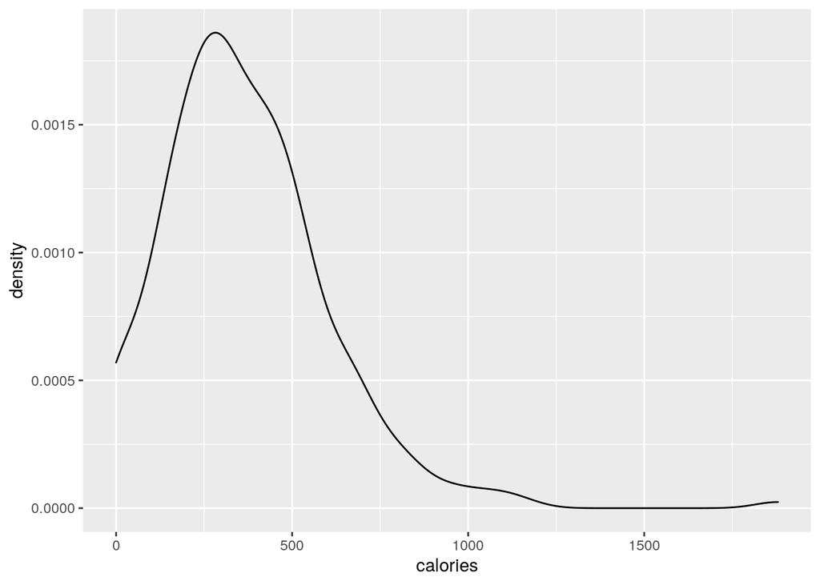

We can see that the data is positively skewed, implying that the mean and standard deviation won’t be appropriate measure for the current data. Therefore in the rest of the report I’ll use more robust methods such as the median and quartiles to measure the location and spread of the variables.

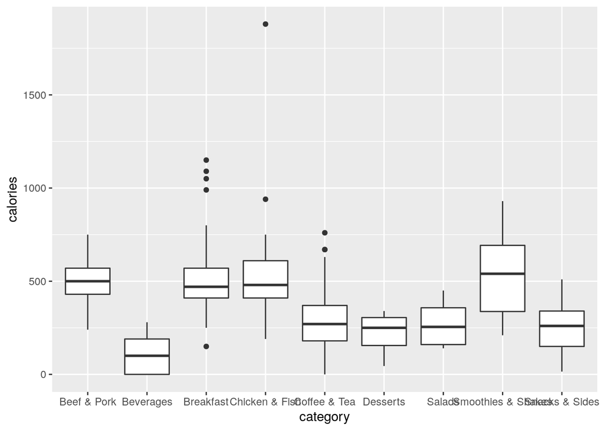

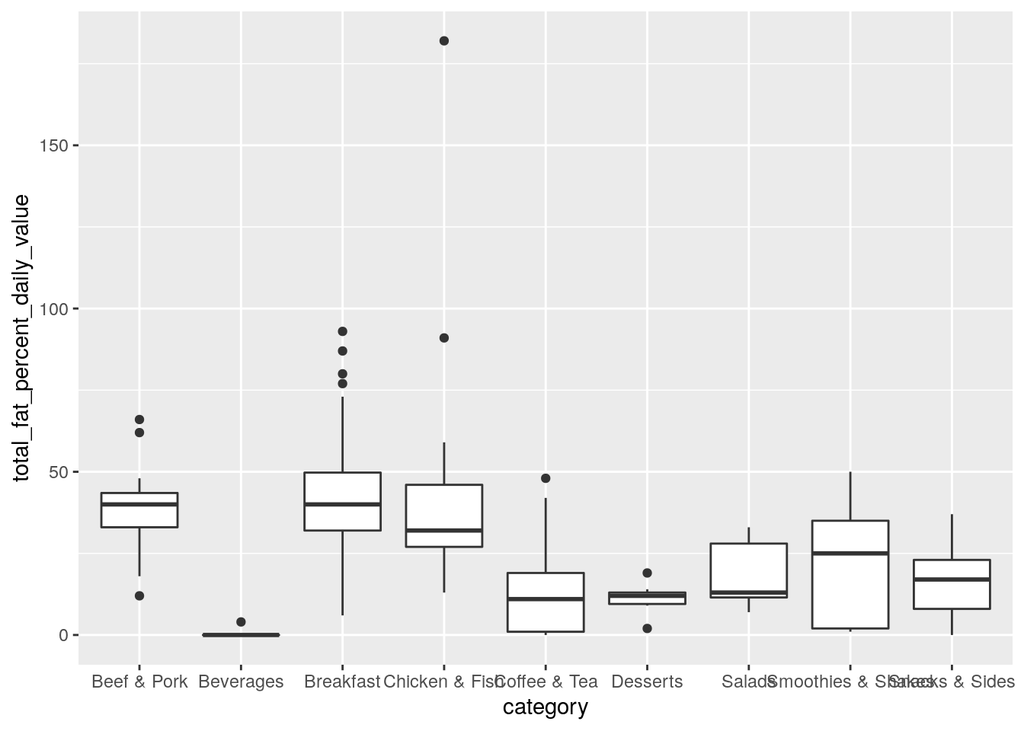

Most meals (comb of sandwich drink and side) add up to around 100% of daily intake

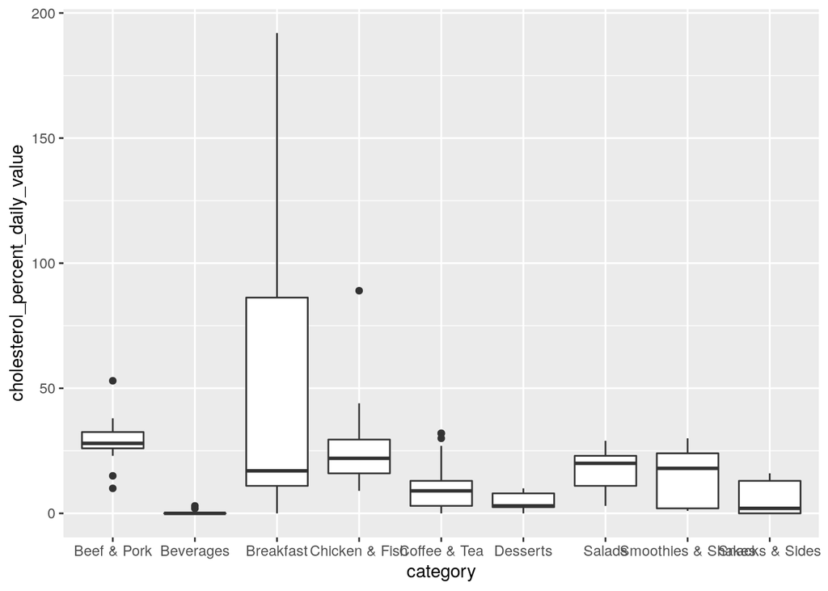

Breakfast menu is very high in cholestrol

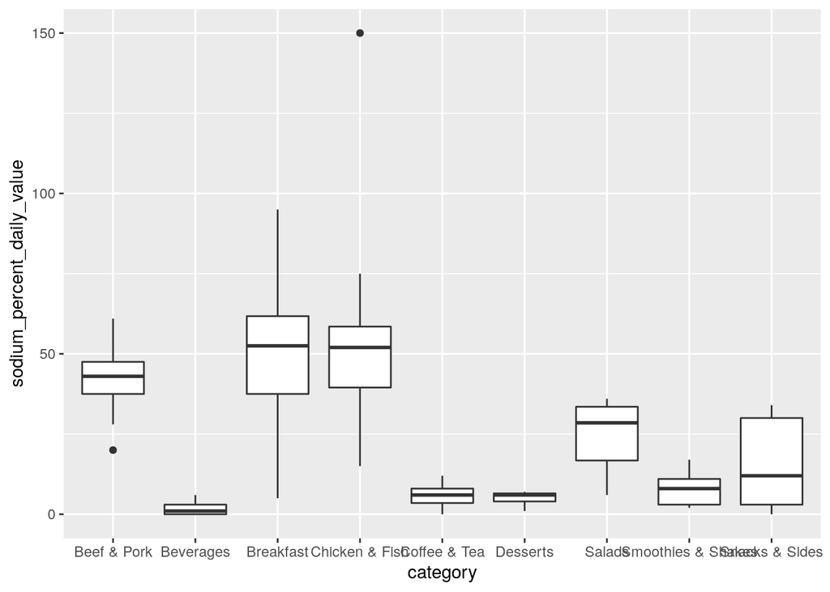

Complete meal would add up to close to 100% daily sodium

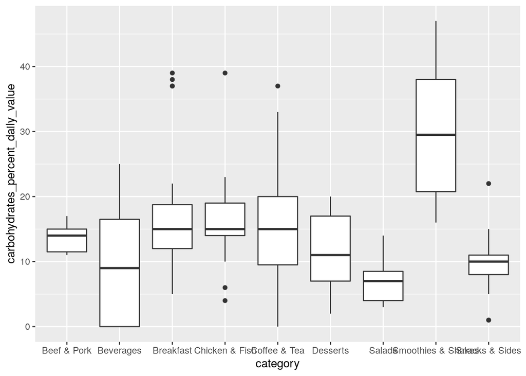

Complete meal would add up to around 50% of daily carb

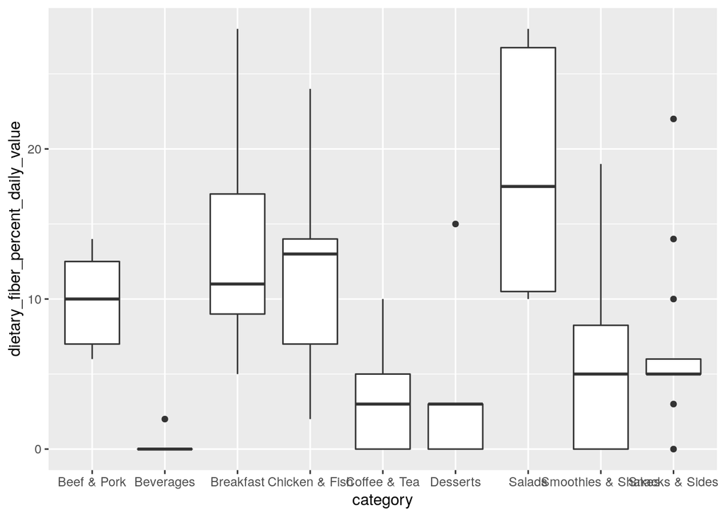

Complete meal would add up to around 25% of daily intake

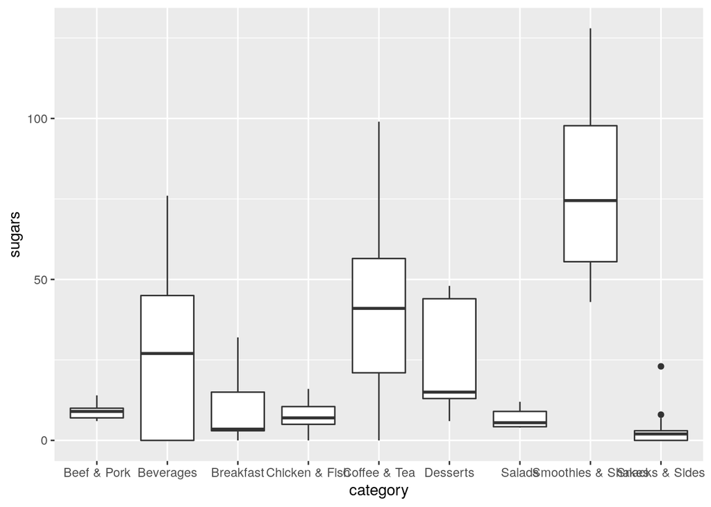

Assuming grams units coffee&tea, deserts, and smoothies&shakes have largest values

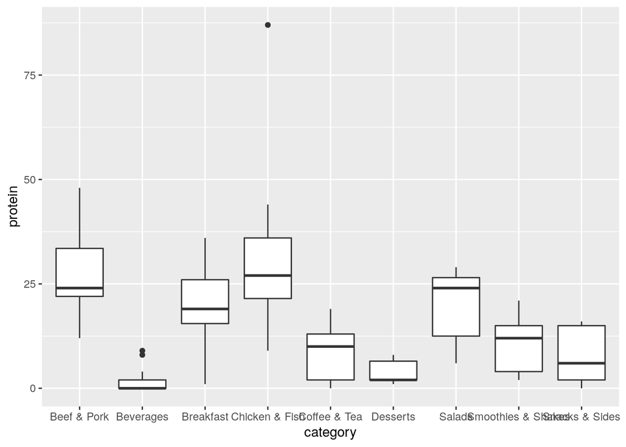

High protein value in complete meals

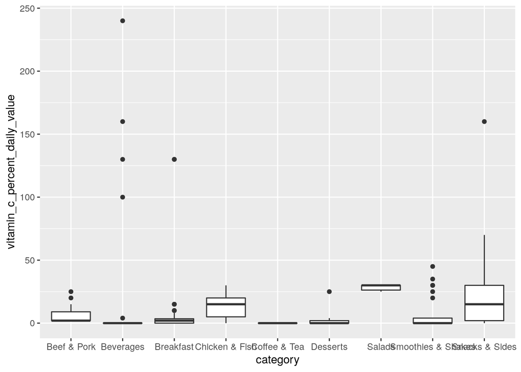

Some drinks have high vitamin c value

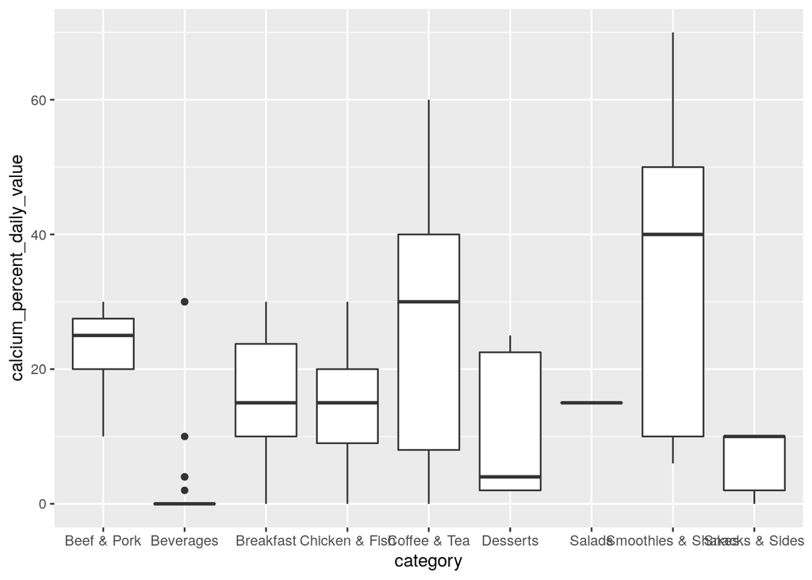

Smoothies, and coffee have high value calcium (since most have milk and other forms of dairy)

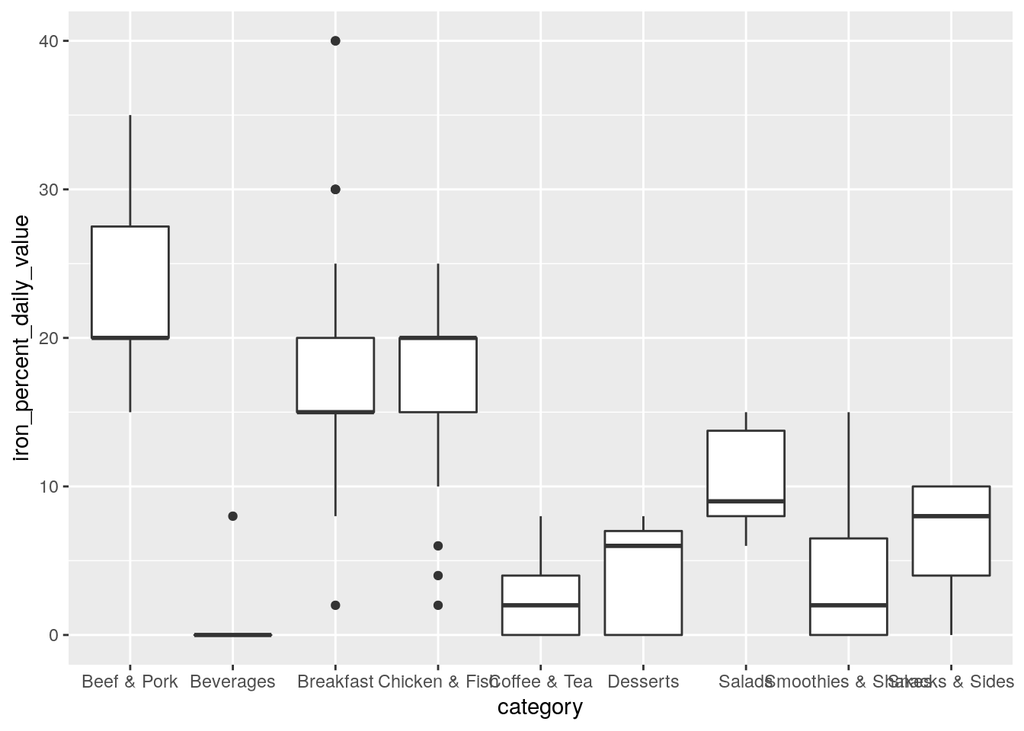

Red meats have high iron values

# Conclusion

Due to the time sensitive nature of the assignment I couldn’t analyse the data as much as I wanted to. Regardless, the data shows that each complete meal (sandwich/salad, drink, and side/dessert) is very high in calories, fat, and sodium. Some categories are rich in nutrients while others aren’t; The breakfast menu is very high in cholesterol, dairy containing drinks have large amounts of calcium, sandwiches (beef&pork, breakfast, and chicken&fish), are high in sodium, and salads are relatively high in fibers. Overall, eating a complete meal from Mcdonalds, will give you an excess amount of relatively unhealthy nutrients while also giving you a decent amount of necessary nutrients.